# In-class exercise: Think of research questions and variables of interest using ELS:2002 data

# 1 Instructions

- Run the below code, which loads libraries and data
- Read the section “ELS:2002 data”, which provides and introduction to ELS:2002 and also presents some example causal research questions using ELS:2002 data (run the code chunks on your own)
- In the section “Think of research questions and variable”, your task is to:
  - write your notes/ideas about dependent variables of interest, independent variables of interest, research questions of interest, populations of interest in the google doc for your group

## 1.1 Load libraries and data

- Loads libraries (install if necessary)
- Runs *R* script that creates data frames from ELS:2002 data

# 2 ELS:2002 data

## 2.1 Intro to ELS:2002 data

The Educational Longitudinal Study (ELS) of 2002, referred to as ELS:2002

- Nationally representative, longitudinal survey of US 10th graders in 2002, followed them from 2002 to 2013
- Created by the National Center for Education Statistics, a branch of the U.S. Department of Education
- [LINK](https://nces.ed.gov/surveys/els2002/) to ELS:2002 website
- [LINK](https://nces.ed.gov/OnlineCodebook) to the NCES “Online Codebook” website, which contains “public-use” versions of ELS datasets and detailed information about all variables
  - variables that could potentially be used to identify ELS survey respondents are “suppressed” from public-use datasets
  - these variables are present in “restricted” versions of ELS datasets

ELS datasets we created

- student-level data frame `df_els_stu_all` has all variables (about 4,000) and all observations (about 16,200 observations); one observation for each student
- student-level data frame `df_els_stu` has a subset of variables and a subset of observations
  - sample is respondents who filled completed all waves of the survey; who attended postsecondary education at some point by 2012; and some other minor sample criteria around observations not being missing for certain variables
- for both `df_els_stu_all` and `df_els_stu`, most categorical variables are `labelled` class variables
- student-level data frame `df_els_stu_fac` is exact same as `df_els_stu` except categorical variables are `factor` class; categorical variables must be factor class when running regression models
- In the coming weeks, we want your help in identifying variables of interest and populations/samples of interest!

Investigate `df_els_stu` (output not shown)

Investigate `df_els_stu_fac`

```r
# variable names
df_els_stu_fac %>% glimpse()
```

```
## Rows: 8,910
## Columns: 94
## $ stu_id        <dbl> 101102, 101104, 101105, 101106, 101108, 101111, 101112, 101115, 101116, 101118, 101121, 101122, 101123, 101126, 101127, 101129, 101131, 101201, 101207, 101210, 101211, 101214, 101223, 102101, 102104, 102106, 102108, 102109, 102111, 102112, 102120, 102121, 102122, 102203, 102…
## $ sch_id        <fct> Suppressed, Suppressed, Suppressed, Suppressed, Suppressed, Suppressed, Suppressed, Suppressed, Suppressed, Suppressed, Suppressed, Suppressed, Suppressed, Suppressed, Suppressed, Suppressed, Suppressed, Suppressed, Suppressed, Suppressed, Suppressed, Suppressed, Suppressed,…
## $ strat_id      <dbl> 101, 101, 101, 101, 101, 101, 101, 101, 101, 101, 101, 101, 101, 101, 101, 101, 101, 101, 101, 101, 101, 101, 101, 102, 102, 102, 102, 102, 102, 102, 102, 102, 102, 102, 102, 102, 102, 102, 102, 102, 102, 102, 102, 102, 102, 102, 102, 102, 102, 102, 103, 103, 103, 103, 103, …
## $ psu           <fct> PSU 1, PSU 1, PSU 1, PSU 1, PSU 1, PSU 1, PSU 1, PSU 1, PSU 1, PSU 1, PSU 1, PSU 1, PSU 1, PSU 1, PSU 1, PSU 1, PSU 1, PSU 2, PSU 2, PSU 2, PSU 2, PSU 2, PSU 2, PSU 1, PSU 1, PSU 1, PSU 1, PSU 1, PSU 1, PSU 1, PSU 1, PSU 1, PSU 1, PSU 2, PSU 2, PSU 2, PSU 2, PSU 2, PSU 2, PS…
## $ f3univ        <chr> "1111", "1111", "1111", "1111", "1111", "1111", "1111", "1111", "1111", "1111", "1111", "1111", "1111", "1111", "1111", "1111", "1111", "1111", "1111", "1111", "1111", "1111", "1111", "1111", "1111", "1111", "1111", "1111", "1111", "1111", "1111", "1111", "1111", "1111", "11…
## $ g10cohrt      <fct> Sophomore cohort member, Sophomore cohort member, Sophomore cohort member, Sophomore cohort member, Sophomore cohort member, Sophomore cohort member, Sophomore cohort member, Sophomore cohort member, Sophomore cohort member, Sophomore cohort member, Sophomore cohort member, …
## $ f1pared       <fct> "Attended college, no 4-year degree", "Graduated from high school or GED", "Graduated from high school or GED", "Did not finish high school", "Graduated from college", "Did not finish high school", "Graduated from college", "Graduated from high school or GED", "Completed Mas…
## $ byincome      <fct> "$75,001-$100,000", "$50,001-$75,000", "$1,000 or less", "$15,001-$20,000", "$50,001-$75,000", "$1,001-$5,000", "$25,001-$35,000", "$25,001-$35,000", "$100,001-$200,000", "$25,001-$35,000", "$75,001-$100,000", "$5,001-$10,000", "$10,001-$15,000", "$25,001-$35,000", "$50,001-…
## $ bystexp       <fct> "Obtain PhD, MD, or other advanced degree", "Don't know", "Graduate from college", "Graduate from college", "Don't know", "Obtain Master's degree or equivalent", "Don't know", "Don't know", "Obtain PhD, MD, or other advanced degree", "Graduate from college", "Obtain Master's…
## $ byparasp      <fct> "Obtain PhD, MD, or other advanced degree", "Obtain PhD, MD, or other advanced degree", "Obtain Master's degree or equivalent", "High school graduation or GED only", "Graduate from college", "High school graduation or GED only", "Graduate from college", "Graduate from colleg…
## $ bytxstat      <fct> Both reading and math, Both reading and math, Both reading and math, Both reading and math, Both reading and math, Both reading and math, Both reading and math, Both reading and math, Both reading and math, Both reading and math, Both reading and math, Both reading and math,…
## $ bypqstat      <fct> Hard copy full questionnaire, Full CATI, Nonrespondent, Full CATI, Abbreviated CATI, Hard copy abbreviated questionnaire, Hard copy full questionnaire, Full CATI, Nonrespondent, Full CATI, Hard copy full questionnaire, Full CATI, Spanish questionnaire, Hard copy full questio…
## $ bytxmstd      <dbl+lbl> 57.65, 66.44, 44.68, 40.57, 50.71, 46.17, 58.76, 64.63, 69.38, 29.98, 57.83, 46.07, 47.74, 66.32, 53.70, 71.38, 59.66, 44.62, 56.96, 65.38, 56.31, 43.60, 47.85, 47.55, 51.95, 35.80, 41.94, 32.99, 39.63, 33.63, 33.11, 31.78, 39.37, 40.55, 41.70, 54.75, 43.00, 28.71, 53.06…
```

[output cut: 81 more lines]

```r
# variable labels
df_els_stu_fac %>% var_label()
```

```
## $stu_id
## [1] "Student ID"
##
## $sch_id
## [1] "School ID"
##
## $strat_id
## [1] "Stratum"
##
## $psu
## [1] "Primary sampling unit"
##
## $f3univ
## [1] "Cross-round sample member status summary (BY to F3)"
##
## $g10cohrt
## [1] "Sophomore cohort member in 2001-2002 school year"
##
## $f1pared
## [1] "F1 parent's highest level of education"
##
## $byincome
## [1] "Total family income from all sources 2001-composite"
##
## $bystexp
## [1] "How far in school student thinks will get-composite"
##
## $byparasp
## [1] "How far in school parent wants 10th-grader to go-composite"
##
## $bytxstat
## [1] "Base year test score status"
##
## $bypqstat
## [1] "Base year parent questionnaire status"
##
## $bytxmstd
## [1] "Math test standardized score"
##
## $bytxrstd
```

[output cut: 226 more lines]

```
##
## $f2enroll0405
## [1] "0/1 (no/yes) enrolled in 2004-05, based on student survey follow-up 2"
##
## $f2enroll0506
## [1] "0/1 (no/yes) enrolled in 2005-06, based on student survey follow-up 2"
##
## $f2intern0405
## [1] "0/1 (no/yes) held an internship or co-op in 2004-05; NA if not enrolled in postsecondary education in 2004-05"
##
## $f2intern0506
## [1] "0/1 (no/yes) held an internship or co-op in 2005-06; NA if not enrolled in postsecondary education in 2005-06"
##
## $parent_income
## [1] "continuous measure of base year parental household income, calculated from categorical variable byincome"
```

## 2.2 Example ELS:2002 research questions

For the multivariate regression lecture, we will focus on using multivariate regression to answer *causal* research questions that follow the form “what is the effect of $X$ on $Y$?”

Example research questions using ELS:2002 data

1. [observational design, categorical $X$] What is the effect of having an internship or co-op job ($X$) (in 2005-06) on 2011 earnings ($Y$)? [for students who were enrolled in postsecondary education in 2005-06]
   - $Y$ is `f3ern2011`
   - $X$ is `f2intern0506` (this would be sophomore year for students who graduated HS in spring 2004 and immediately entered postsecondary education)
     - `f2intern0506==0`: no co-op/internship
   - sample: `f2enroll0506=='yes'`

```r
df_els_stu_fac %>% filter(f2enroll0506=='yes') %>%
  group_by(f2intern0506) %>% summarize(
  mean_earn = mean(f3ern2011, na.rm = TRUE),
  n_nonmissing = sum(!is.na(f3ern2011))
)
```

```
## # A tibble: 3 x 3
##   f2intern0506 mean_earn n_nonmissing
##   <fct>            <dbl>        <int>
## 1 no              28764.         6858
## 2 yes             33863.          450
## 3 <NA>            34000            11
```

2. [observational design, categorical $X$] What is the effect of field of study ($X$) on earnings ($Y$)? [for respondents not currently enrolled in postsecondary education]
   - answer the RQ separately for: certificate degrees; associate’s degrees; for bachelor’s degrees?
   - $Y$ is `f3ern2011`
   - for certificate degrees: $X$ is `f3tzcrt1cip2`
   - for associate’s degrees: $X$ is `f3tzasc1cip2`
   - for bachelor’s degrees: $X$ is `f3tzbch1cip2`

```r
# certificate degrees
df_els_stu_fac %>% filter(!(f3tzcrt1cip2 %in% c('Missing','Item legitimate skip/NA')), f3a01d=='No') %>%
  group_by(f3tzcrt1cip2) %>% summarize(
  mean_earn = mean(f3ern2011, na.rm = TRUE),
  n_nonmissing = sum(!is.na(f3ern2011))
)
```

```
## # A tibble: 5 x 3
##   f3tzcrt1cip2                             mean_earn n_nonmissing
##   <fct>                                        <dbl>        <int>
## 1 Personal and culinary services              20797.           86
## 2 Mechanic/repair technologies/technicians    31174.           53
## 3 Health/related clinical sciences            20842.          241
## 4 Business/management/marketing/related       29976.           21
## 5 Other                                       31565.          108
```

```r
# associates degreees
df_els_stu_fac %>% filter(!(f3tzasc1cip2 %in% c('Missing','Item legitimate skip/NA')), f3a01d=='No') %>%
  group_by(f3tzasc1cip2) %>% summarize(
  mean_earn = mean(f3ern2011, na.rm = TRUE),
  n_nonmissing = sum(!is.na(f3ern2011))
)
```

```
## # A tibble: 11 x 3
##    f3tzasc1cip2                             mean_earn n_nonmissing
##    <fct>                                        <dbl>        <int>
##  1 Computer/information science/support        29923.           26
##  2 Personal and culinary services              26161.           31
##  3 Education                                   16517.           30
##  4 Engineering technologies/technicians        29593.           28
##  5 Liberal arts/sci/gen studies/humanities     24622.          218
##  6 Security and protective services            27756.           39
##  7 Mechanic/repair technologies/technicians    38006.           35
##  8 Visual and performing arts                  19403.           31
##  9 Health/related clinical sciences            29003.          151
## 10 Business/management/marketing/related       33240.          107
## 11 Other                                       28303.           88
```

```r
# bachelor's degreees
df_els_stu_fac %>% filter(!(f3tzbch1cip2 %in% c('Missing','Item legitimate skip/NA')), f3a01d=='No') %>%
  group_by(f3tzbch1cip2) %>% summarize(
  mean_earn = mean(f3ern2011, na.rm = TRUE),
  n_nonmissing = sum(!is.na(f3ern2011))
) %>% print(n=30)
```

```
## # A tibble: 27 x 3
##    f3tzbch1cip2                             mean_earn n_nonmissing
##    <fct>                                        <dbl>        <int>
##  1 Agriculture/operations/related sciences     30788.           33
##  2 Natural resources and conservation          27828.           29
##  3 Architecture and related services           30478.           23
##  4 Communication, journalism, related          31085.          240
##  5 Computer/information science/support        44458.           60
##  6 Education                                   29519.          185
##  7 Engineering                                 51410.          156
##  8 Engineering technologies/technicians        44267.           36
##  9 Foreign languages/literature/linguistics    32247.           45
## 10 Family/consumer sciences/human sciences     26189.           53
## 11 English language and literature/letters     24202.           96
## 12 Liberal arts/sci/gen studies/humanities     29733.           45
## 13 Biological and biomedical sciences          20472.          137
## 14 Mathematics and statistics                  38931.           36
## 15 Multi/interdisciplinary studies             25251.           66
## 16 Parks/recreation/leisure/fitness studies    26736.          106
## 17 Philosophy and religious studies            23977.           22
## 18 Physical sciences                           33311.           37
## 19 Psychology                                  25680.          176
## 20 Security and protective services            36736.           70
## 21 Public administration/social service        26639.           61
## 22 Social sciences                             32916.          318
## 23 Visual and performing arts                  24297.          215
## 24 Health/related clinical sciences            42889.          264
## 25 Business/management/marketing/related       41515.          751
## 26 History                                     25771.           75
## 27 Other                                       29107.           61
```

3. [observational design, continuous $X$] What is the effect of amount borrowed in student loans ($X$) on earnings ($Y$) for respondents not currently enrolled in postsecondary education
   - $X$ var is `f3totloan`; $Y$ var is `f3ern2011`
   - sample: `f3a01d=='No'`

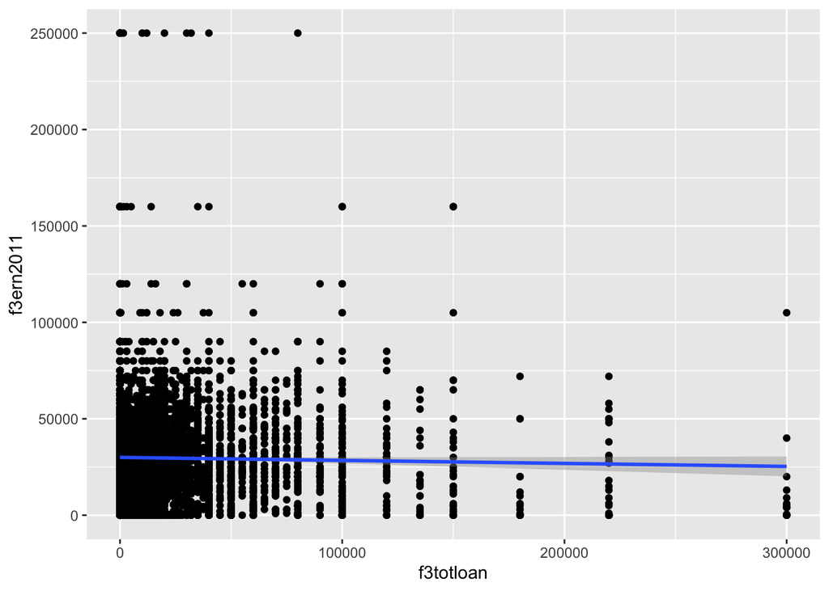

```r
df_els_stu_fac %>% filter(f3a01d=="No") %>%  ggplot(aes(x=f3totloan, y=f3ern2011)) + geom_point() + stat_smooth(method = 'lm')
```

```r
summary(lm(formula = f3ern2011 ~ f3totloan, data = df_els_stu %>% filter(f3a01d==0)))
```

```
##
## Call:
## lm(formula = f3ern2011 ~ f3totloan, data = df_els_stu %>% filter(f3a01d ==
##     0))
##
## Residuals:
##    Min     1Q Median     3Q    Max
## -29971 -16577  -3769  10351 221273
##
## Coefficients:
##                 Estimate   Std. Error t value            Pr(>|t|)
## (Intercept) 29971.343400   358.117571  83.691 <0.0000000000000002 ***
## f3totloan      -0.015558     0.009277  -1.677              0.0936 .
## ---
## Signif. codes:  0 '***' 0.001 '**' 0.01 '*' 0.05 '.' 0.1 ' ' 1
##
## Residual standard error: 25220 on 6601 degrees of freedom
## Multiple R-squared:  0.0004259,  Adjusted R-squared:  0.0002745
## F-statistic: 2.813 on 1 and 6601 DF,  p-value: 0.09356
```

Why are we using earnings as the dependent variable?

- Ordinary Least Squares (OLS) multivariate regression assumes continuous dependent variable; regression models with categorical dependent variables are a bit more difficult to interpret
- But in later weeks, we may introduce the “linear probability model,” which will enable us to model dichotomous (two-category) dependent variables (e.g., 0/1 did student graduate)

# 3 Think of variables and research questions of interest

Your task is to:

- think of potential dependent variables of interest and potential independent variables of interest
  - some of these variables may already be in the data frame `els_stu_fac`; some may be in the larger data frame `els_stu_all`, and I can add them to `els_stu_fac` in subsequent weeks
  - dependent variables can be continous or dichotomous (two categories)
  - independent variables should be variables that could be (in theory) randomly assigned in a random assignment experiment
- think of potential causal research questions of interest that follow the form “what is the effect of X on Y”
  - you may think about what sample/population of students this research questions pertains to
- write your notes/ideas about dependent variables of interest, independent variables of interest, research questions of interest, populations of interest in the google doc for your group;
  - doesn’t have to be polished! But I’ll use your ideas when thinking about which variables to add to `els_stu_fac`, and when thinking about questions for the take-home final exam (I want research questions that speak to your interests)

Can use the `lookfor()` function from the `labelled` package to query which variables and variable labels contain certain words

- syntax (with defaults):
  - `look_for(data, ..., labels = TRUE, ignore.case = TRUE, details = TRUE)`
  - where argument `...` contains “strings” (e.g., words) you are looking for, enclosed in quotation marks
- example syntax, looking for variable names and variable labels that contain the word “internship”
  - `lookfor(data=df_els_stu_all, 'internship',labels = TRUE, ignore.case = TRUE, details = TRUE)`

useful to use `lookfor()` to query the dataset `df_els_stu_all` because this dataset has so many variables (more than 4,000)

```r
# query data frame df_els_stu_all
  lookfor(data=df_els_stu_all, 'internship',labels = TRUE, ignore.case = TRUE, details = TRUE)
```

```
## # A tibble: 6 x 13
##     pos variable label                                                                            col_type class        type   levels       value_labels na_values    na_range     unique_values  n_na range
##   <int> <chr>    <chr>                                                                            <chr>    <named list> <chr>  <named list> <named list> <named list> <named list>         <int> <int> <named list>
## 1   388 f1r51_c  Units in executive internship                                                    dbl+lbl  <chr [3]>    double <NULL>       <dbl [1]>    <NULL>       <NULL>                   1     0 <dbl+lbl [2]>
## 2  1544 bys71b   Participated in internship                                                       dbl+lbl  <chr [3]>    double <NULL>       <dbl [6]>    <NULL>       <NULL>                   6     0 <dbl+lbl [2]>
## 3  2399 f2c25a   Held internship or co-op job while enrolled in 2004-2005 school year             dbl+lbl  <chr [3]>    double <NULL>       <dbl [7]>    <NULL>       <NULL>                   7     0 <dbl+lbl [2]>
## 4  2408 f2c30a   Held internship or co-op job while enrolled in 2005-2006 school year             dbl+lbl  <chr [3]>    double <NULL>       <dbl [7]>    <NULL>       <NULL>                   7     0 <dbl+lbl [2]>
## 5  2506 f3a14a   High-impact PS activities:  Internship/co-op/field experience/student teaching/c dbl+lbl  <chr [3]>    double <NULL>       <dbl [7]>    <NULL>       <NULL>                   7     0 <dbl+lbl [2]>
## 6  3348 bya18b   Internships offered to 10th-graders                                              dbl+lbl  <chr [3]>    double <NULL>       <dbl [6]>    <NULL>       <NULL>                   6     0 <dbl+lbl [2]>
```

```r
# query data frame df_els_stu
  lookfor(data=df_els_stu, 'debt',labels = TRUE, ignore.case = TRUE, details = TRUE)
```

```
## # A tibble: 0 x 0
```

```r
  lookfor(data=df_els_stu, 'loan',labels = TRUE, ignore.case = TRUE, details = TRUE)
```

```
## # A tibble: 4 x 13
##     pos variable    label                                                                    col_type class        type   levels       value_labels na_values    na_range     unique_values  n_na range
##   <int> <chr>       <chr>                                                                    <chr>    <named list> <chr>  <named list> <named list> <named list> <named list>         <int> <int> <named list>
## 1    85 f3stloanamt Total amount borrowed in student loans                                   dbl+lbl  <chr [3]>    double <NULL>       <dbl [3]>    <NULL>       <NULL>                  58     0 <dbl+lbl [2]>
## 2    86 f3stloanevr Whether R took out any student/PSE loans                                 dbl+lbl  <chr [3]>    double <NULL>       <dbl [6]>    <NULL>       <NULL>                   2     0 <dbl+lbl [2]>
## 3    87 f3stloanpay Amount currently paid monthly toward student loan balance                dbl+lbl  <chr [3]>    double <NULL>       <dbl [3]>    <NULL>       <NULL>                  41     0 <dbl+lbl [2]>
## 4    89 f3totloan   total loans taken out to pay for postsecondary education as of f3 (2013) dbl      <chr [1]>    double <NULL>       <NULL>       <NULL>       <NULL>                  58     0 <dbl [2]>
```

Investigate `df_els_stu_fac` (output not shown)